# Reproducible Research - Course Assignment 1

### Before starting

Loading libraries

```r
library(ggplot2)
library(lubridate)
library(dplyr)
```

## Step 1: Loading data

- Loading the downloaded data.
- ‘Date’ column was reformatted using lubridate package.
- Then, tabulate number of steps taken per day to compute mean total number of steps per day. Records with ‘NA’ value were removed from the data.

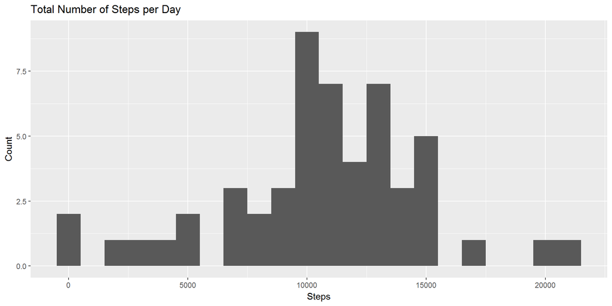

```r
step_data <- read.csv('activity.csv')
step_data$date <- ymd(step_data$date)
step_daily <- with(step_data[step_data$steps != 'NA', ],
                   aggregate(list(total_steps = steps), list(date = date), FUN = sum))

#What is mean total number of steps taken per day?
ggplot(step_daily) + aes(x = total_steps) + geom_histogram(binwidth = 1000) +
    labs(title='Total Number of Steps per Day', x = 'Steps', y = 'Count')
```

- The mean of total daily steps is **10766**.
- The median of total daily steps is **10765**.

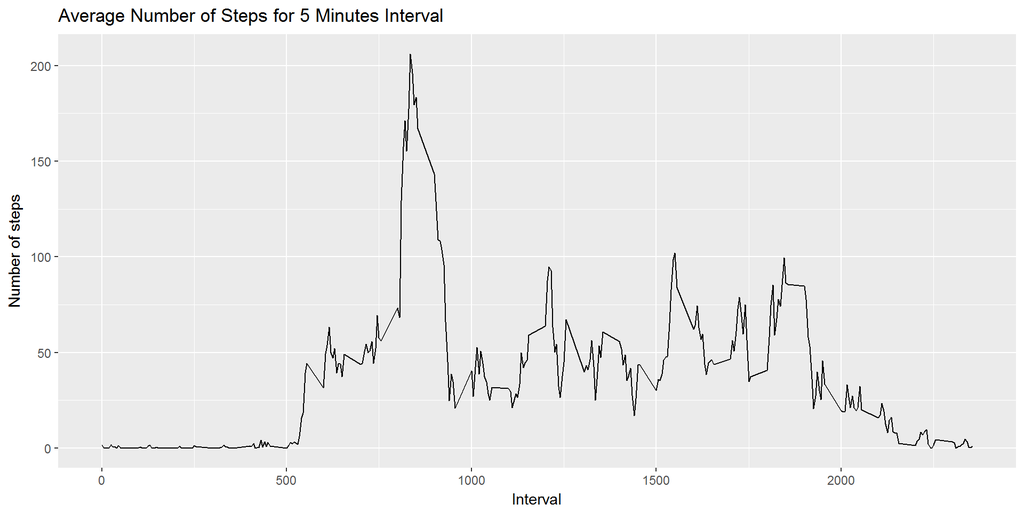

```r
step_interval <- step_data %>%
    group_by(interval) %>%
    summarise(average_steps = mean(steps, na.rm =TRUE))

#What is the average daily activity pattern?
ggplot(step_interval) + aes(y = average_steps, x = interval) + geom_line() +
    labs(title ='Average Number of Steps for 5 Minutes Interval', x = 'Interval', y = 'Number of steps')
```

## Step 2: Filling NAs

- The total number of NAs/ missing values is **2304**
- All of the missing values are filled with the median steps for each interval. The median steps are computed without taking into account the NAs/ missing values.
- Replot the histogram of total number of steps taken each data and recalculate the mean and median total number os steps taken per day.

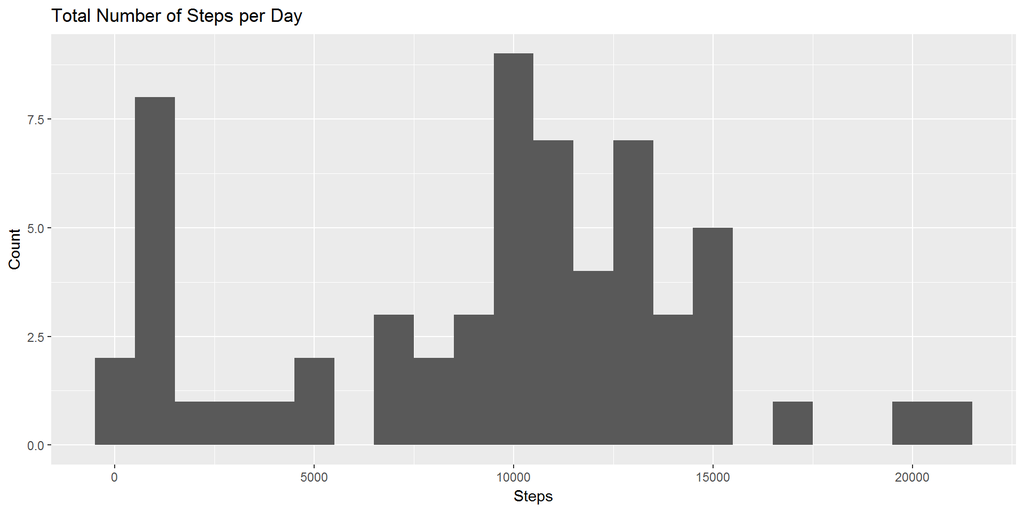

```r
step_interval_median <- aggregate(list(median_steps = step_data$steps),
                                  by = list(interval = as.factor(step_data$interval)),
                                  FUN = median, na.rm = TRUE)

step_data_noNA <- step_data %>%
    mutate(steps = ifelse(is.na(steps),
                          step_interval_median[as.factor(interval), 2],
                          steps),
           weekend = ifelse(weekdays(date, abbreviate = TRUE) %in% c('Sun', 'Sat'),
                            'Weekends',
                            'Weekdays'))

step_daily_noNA <- step_data_noNA %>%
    group_by(date, weekend) %>%
    summarise(total_steps = sum(steps))

ggplot(step_daily_noNA) + aes(x = total_steps) + geom_histogram(binwidth = 1000) +
    labs(title ='Total Number of Steps per Day', x = 'Steps', y = 'Count')
```

- The mean of total daily steps taken per day is **9503**. It is **lower** than that before filling the missing values.
- The median of total daily steps taken per day is **10395**. It is **lower** than that before filling the missing values.
- Ploting average steps taken for each interval during weekdays and weekends.

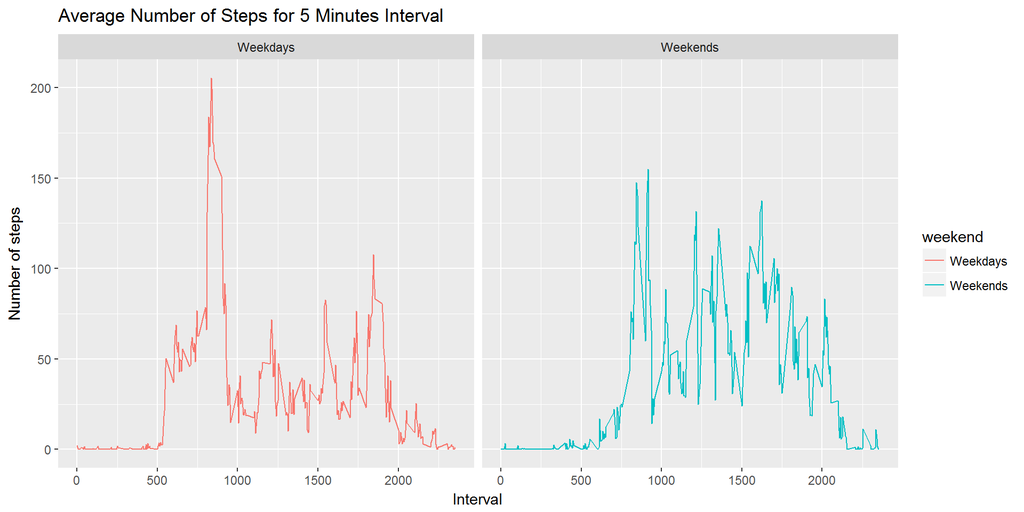

```r
step_interval_wkday <- step_data_noNA %>%
    group_by(interval, weekend) %>%
    summarise(average_steps = mean(steps))

#What is the average daily activity pattern for weekends and weekdays
ggplot(step_interval_wkday) + aes(y = average_steps, x = interval, color = weekend) + facet_grid(. ~ weekend) + geom_line() +
    labs(title ='Average Number of Steps for 5 Minutes Interval', x = 'Interval', y = 'Number of steps')
```